# Analysis of Cross Sectional Dative Priming

```r
library(brms)
library(readxl)
library(rmarkdown)
library(tidybayes)
library(ggplot2)
library(tidyr)
library(dplyr)
library(GGally)
library(ggpubr)
library(tidybayes)
library(patchwork)
library(sjPlot)
XSectional <- read_excel("DOD Priming Data Sheet_Wgender_May42020 (1).xlsx")
```

# 1 Some preliminary stuff

## 1.1 Missing data

Invalid trials

```r
XSectional %>%
  filter(trial_drop==1)
```

| Part_No | Case_ID | Gender | Age | List | Item | Prime_verb | Trial_verb | Prime_type | Verb_match | Response | Ravens | PPVT | Notes | drop | part_drop | trial_drop | Admin.Error | Verb.error | Non.allowable.prompt | Non.Target.Response | Attentiveness |
| --- | --- | --- | --- | --- | --- | --- | --- | --- | --- | --- | --- | --- | --- | --- | --- | --- | --- | --- | --- | --- | --- |
| 75 | hp_01 | 1 | 8.720000 | 1 | 10 | brought | brought | 0.5 | 0.5 | NA | 30 | 131 | exp. error - slide did not play. | 1 | NA | 1 | 1 | NA | NA | NA | NA |
| 76 | hp_02 | 0 | 5.810000 | 2 | 2r | brought | showed | -0.5 | -0.5 | NA | 25 | 100 | did not repeat trial verb | 1 | NA | 1 | NA | 1 | NA | NA | NA |
| 76 | hp_02 | 0 | 5.810000 | 2 | 4r | showed | showed | 0.5 | 0.5 | NA | 25 | 100 | did not repeat trial verb | 1 | NA | 1 | NA | 1 | NA | NA | NA |
| 85 | lm_11 | 1 | 4.400000 | 3 | 2 | showed | brought | -0.5 | -0.5 | 1 | 14 | 87 | Exp error | 1 | NA | 1 | 1 | NA | NA | NA | NA |
| 85 | lm_11 | 1 | 4.400000 | 3 | 4 | showed | showed | 0.5 | 0.5 | 1 | 14 | 87 | Exp error | 1 | NA | 1 | 1 | NA | NA | NA | NA |
| 86 | cv_12 | 1 | 4.600000 | 4 | 2r | brought | showed | -0.5 | -0.5 | 0 | 15 | 79 | Exp error | 1 | NA | 1 | 1 | NA | NA | NA | NA |
| 86 | cv_12 | 1 | 4.600000 | 4 | 3r | threw | threw | 0.5 | 0.5 | 0 | 15 | 79 | Exp error | 1 | NA | 1 | 1 | NA | NA | NA | NA |
| 90 | cv_16 | 1 | 4.370000 | 8 | 3r | threw | threw | -0.5 | 0.5 | 0 | 12 | 92 | DOD on first response but wrong verb/ After re-promting with sentence start responded POD | 1 | NA | 1 | 1 | NA | NA | NA | NA |
| 92 | cv_18 | 1 | 4.350000 | 2 | 1r | passed | passed | -0.5 | 0.5 | 0 | 16 | 86 | replay/ lots of prompting to begin | 1 | NA | 1 | NA | NA | NA | TRUE | NA |
| 92 | cv_18 | 1 | 4.350000 | 2 | 9r | passed | sent | 0.5 | -0.5 | 0 | 16 | 86 | inserted own verb/ completed sentence afterwards | 1 | NA | 1 | NA | 1 | NA | NA | NA |

[output cut: 12 more lines]

Total invalid trial types. Total number of invalid trials per participant.

```r
XSectional %>%
  filter(trial_drop==1) %>%
  summarise(
    A_Error = sum(Admin.Error, na.rm = TRUE),
    V_Error = sum(Verb.error, na.rm = TRUE),
    Non_allow = sum(Non.allowable.prompt==TRUE, na.rm = TRUE),
    N_Targ = sum(Non.Target.Response == TRUE, na.rm = TRUE),
    Attn = sum(Attentiveness == TRUE, na.rm = TRUE)
  )
```

| A_Error | V_Error | Non_allow | N_Targ | Attn |
| --- | --- | --- | --- | --- |
| 10 | 6 | 1 | 4 | 1 |

```r
XSectional %>%
  group_by(Part_No) %>%
  mutate(
    n_miss = sum(trial_drop, na.rm = TRUE)
  ) %>%
  slice(1) %>%
  ungroup(Part_No) %>%
  filter(n_miss > 0) %>%
  dplyr::select(Case_ID, List, trial_drop, n_miss)
```

| Case_ID | List | trial_drop | n_miss |
| --- | --- | --- | --- |
| hp_01 | 1 | NA | 1 |
| hp_02 | 2 | NA | 2 |
| lm_11 | 3 | NA | 2 |
| cv_12 | 4 | NA | 2 |
| cv_16 | 8 | NA | 1 |
| cv_18 | 2 | 1 | 2 |
| stm_02 | 5 | NA | 1 |
| sta_03 | 5 | NA | 2 |
| llab_04 | 4 | NA | 1 |
| llab_07 | 7 | 1 | 4 |

[output cut: 3 more lines]

Drop invalid-trials plus invalid participants.

```r
XSectional <- subset(XSectional, drop != 1)
```

## 1.2 Descriptive Statistics

### 1.2.1 Continuous

We’re not planning on using raven’s progressive matrices or the PPVT for any analyses, but I’m leaving them in here for anyone interested in conducting exploratory analyses. These have not been age standardized yet.

```r
XSectional %>%
  group_by(Part_No) %>%
  slice(1) %>%
  ungroup() %>%
  select("Age", "PPVT", "Ravens") %>%
  get_summary_stats(type="common")
```

| variable | n | min | max | median | iqr | mean | sd | se | ci |
| --- | --- | --- | --- | --- | --- | --- | --- | --- | --- |
| Age | 140 | 3.258 | 8.72 | 5.936 | 2.203 | 5.957 | 1.313 | 0.111 | 0.219 |
| PPVT | 140 | 10.000 | 158.00 | 118.500 | 39.000 | 115.643 | 25.594 | 2.163 | 4.277 |
| Ravens | 132 | 9.000 | 35.00 | 21.000 | 11.000 | 21.439 | 6.563 | 0.571 | 1.130 |

Look at marginal and conditional distributions for each variable.

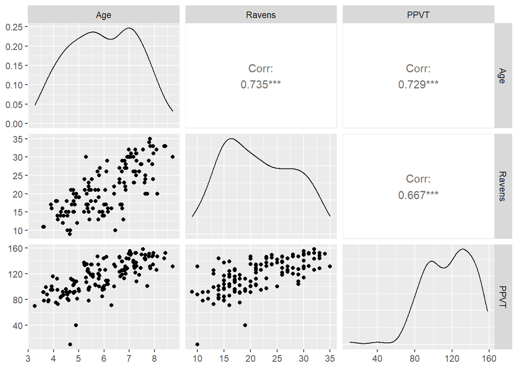

```r
XSectional %>%
  group_by(Part_No) %>%
  slice(1) %>%
  ungroup() %>%
  select(Age, Ravens, PPVT) %>%
  ggpairs()
```

Looks like there are a couple outliers on the PPVT.

### 1.2.2 Categorical

Get number of trials for each cell type

```r
XSectional <- XSectional %>%
 mutate(
    Prime = ifelse(Prime_type==.5, yes="DOD", no="POD"),
    Overlap = ifelse(Verb_match==.5, yes="Overlap", no="No Overlap")
    )


XSectional  %>%
  group_by(Prime, Trial_verb) %>%
  summarise( n = n()
             )
```

| Prime | Trial_verb | n |
| --- | --- | --- |
| DOD | brought | 136 |
| DOD | gave | 140 |
| DOD | passed | 140 |
| DOD | sent | 137 |
| DOD | showed | 136 |
| DOD | threw | 140 |
| POD | brought | 138 |
| POD | gave | 140 |
| POD | passed | 137 |
| POD | sent | 139 |

[output cut: 2 more lines]

```r
XSectional  %>%
  group_by(Overlap, Trial_verb) %>%
   summarise(
    n = n()
  )
```

| Overlap | Trial_verb | n |
| --- | --- | --- |
| No Overlap | brought | 136 |
| No Overlap | gave | 140 |
| No Overlap | passed | 138 |
| No Overlap | sent | 137 |
| No Overlap | showed | 136 |
| No Overlap | threw | 140 |
| Overlap | brought | 138 |
| Overlap | gave | 140 |
| Overlap | passed | 139 |
| Overlap | sent | 139 |

[output cut: 2 more lines]

```r
XSectional %>%
  group_by(Item) %>%
   summarise(
    n = n()
  )
```

| Item | n |
| --- | --- |
| 1 | 72 |
| 10 | 70 |
| 10r | 68 |
| 11 | 71 |
| 11r | 68 |
| 12 | 72 |
| 12r | 67 |
| 1r | 67 |
| 2 | 68 |
| 2r | 65 |

[output cut: 14 more lines]

```r
XSectional %>%
  group_by(List) %>%
   summarise(
    n = n()
  )
```

| List | n |
| --- | --- |
| 1 | 238 |
| 2 | 200 |
| 3 | 202 |
| 4 | 201 |
| 5 | 199 |
| 6 | 228 |
| 7 | 212 |
| 8 | 178 |

Create Prime bias variable. Note we will use this same characterization for the second study, with longitudinal data as I’m worried about controlling for a post-treatment variable.

```r
XSectional$Agec = XSectional$Age - mean(XSectional$Age)

XSectional$bias <-"DOD"

XSectional %>%
  group_by(Trial_verb) %>%
  summarise(mean = mean(Response, na.rm=TRUE))
```

| Trial_verb | mean |
| --- | --- |
| brought | 0.2481752 |
| gave | 0.3678571 |
| passed | 0.1949458 |
| sent | 0.1449275 |
| showed | 0.4065934 |
| threw | 0.1366906 |

```r
XSectional$bias[XSectional$Prime_verb=="passed"] = "POD"
XSectional$bias[XSectional$Prime_verb=="sent"] = "POD"
XSectional$bias[XSectional$Prime_verb=="threw"] = "POD"
```

```r
XSectional$Bias_POD <- ifelse(XSectional$bias=="POD", yes = .5, no=-.5 )
```

```r
table(XSectional$bias, XSectional$Overlap, XSectional$Prime_type )
```

```
## , ,  = -0.5
##
##
##       No Overlap Overlap
##   DOD        208     206
##   POD        205     210
##
## , ,  = 0.5
##
##
##       No Overlap Overlap
##   DOD        202     209
##   POD        212     206
```

```r
XSectional$biasmatch <-"match"

XSectional$biasmatch[XSectional$bias=="POD" & XSectional$Prime == "DOD"] = "mismatch"
XSectional$biasmatch[XSectional$bias=="DOD" & XSectional$Prime == "POD"] = "mismatch"

table(XSectional$biasmatch)
```

```
##
##    match mismatch
##      826      832
```

```r
XSectional$biasmismatchc <- ifelse(XSectional$biasmatch == "mismatch", yes=.5, no=-.5)

table(XSectional$biasmatch,  XSectional$Overlap, XSectional$Prime_type)
```

```
## , ,  = -0.5
##
##
##            No Overlap Overlap
##   match           205     210
##   mismatch        208     206
##
## , ,  = 0.5
##
##
##            No Overlap Overlap
##   match           202     209
##   mismatch        212     206
```

### 1.2.3 Plots of DoDs produced in each condition.

Now let’s look at the plots of the proportion of DoDs produced for the two two-way interactions. We’ll start with prime and overlap, i.e., the *lexical boost*.

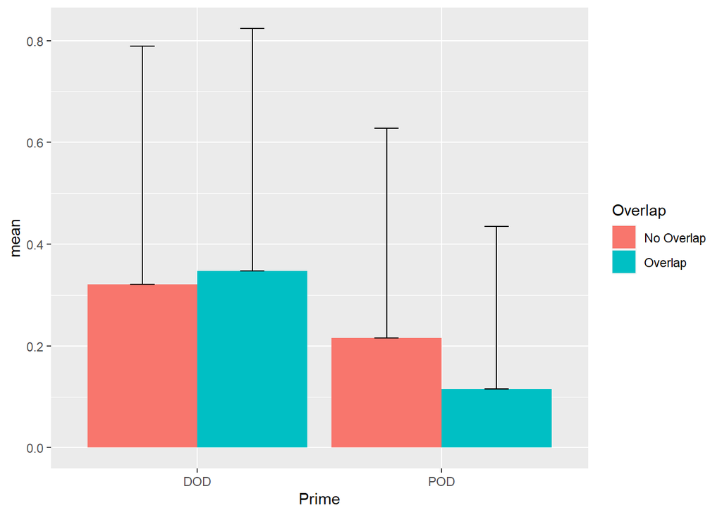

```r
XSectional %>%
  group_by(Prime, Overlap) %>%
  summarise(mean = mean(Response, na.rm=TRUE),
            sd = sd(Response, na.rm=TRUE)) %>%

ggplot(aes(y=mean, x=Prime, fill=Overlap)) +
  geom_bar(stat="identity",position="dodge") +
 geom_errorbar(aes(ymin=mean, ymax=mean+sd), width=.2,
                 position=position_dodge(.9))
```

And we’ll disaggregate by verb to make sure they’re all fairly similar.

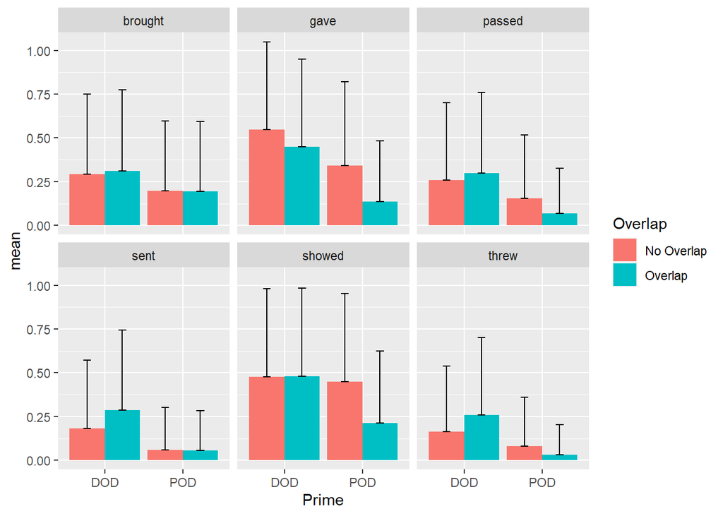

```r
XSectional %>%
  group_by(Prime, Overlap, Trial_verb) %>%
  summarise(mean = mean(Response, na.rm=TRUE),
            sd = sd(Response, na.rm=TRUE)) %>%

ggplot(aes(y=mean, x=Prime, fill=Overlap)) +
  geom_bar(stat="identity",position="dodge") +
 geom_errorbar(aes(ymin=mean, ymax=mean+sd), width=.2,
                 position=position_dodge(.9)) +
  facet_wrap(~Trial_verb)
```

Similar pattern for lexical boost in each condition: bigger effect of lexical boost in each condition, though not visibly obvious in all conditions. There are certainly not some verbs showing the opposite pattern.

Ok now time to look at prime bias

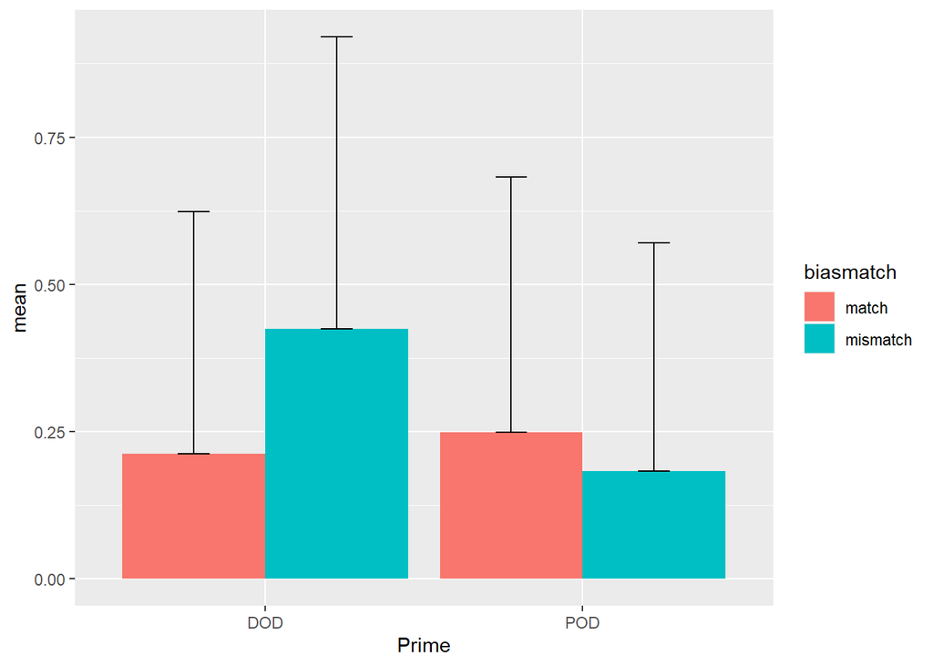

```r
XSectional %>%
  filter(Overlap=="No Overlap") %>%
  group_by(Prime, biasmatch) %>%
  summarise(mean = mean(Response, na.rm=TRUE),
            sd = sd(Response, na.rm=TRUE)) %>%

ggplot(aes(y=mean, x=Prime, fill=biasmatch)) +
  geom_bar(stat="identity",position="dodge") +
 geom_errorbar(aes(ymin=mean, ymax=mean+sd), width=.2,
                 position=position_dodge(.9))
```

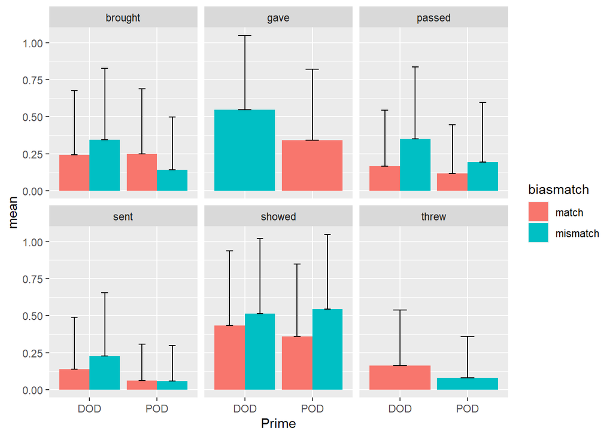

```r
XSectional %>%
  filter(Overlap=="No Overlap") %>%
  group_by(Prime, biasmatch, Trial_verb) %>%
  summarise(mean = mean(Response, na.rm=TRUE),
            sd = sd(Response, na.rm=TRUE)) %>%

ggplot(aes(y=mean, x=Prime, fill=biasmatch)) +
  geom_bar(stat="identity",position="dodge") +
 geom_errorbar(aes(ymin=mean, ymax=mean+sd), width=.2,
                 position=position_dodge(.9)) +
  facet_wrap(~Trial_verb)
```

It’s a big more difficult to figure out what’s going on here. For a couple reasons.

First: the target verb **threw** was always primed with either**brought** or **showed**, both of which DOD biased. As a result, bias mistmatch is confounded with prime structure within the target verb threw. Likewise **gave** was always primed by **passed** or **sent** both of which are POD biased. As such prime bias is confounded with prime structure with verb. Neither of these structures are confounded within the whole data set – but this might make estimating an interaction between prime bias and prime structure within trial type difficult. Of the four unconfounded verbs, we see the predicted effect for three priming effects are larger for mismatching conditions than matching conditions for **brought**, **passed** and **sent** but not **showed**. If anything **showed** illustrates the opposite effect, but this is a bit hard to see visually, as it seems to producing a lot of DODs in all 4 conditions.

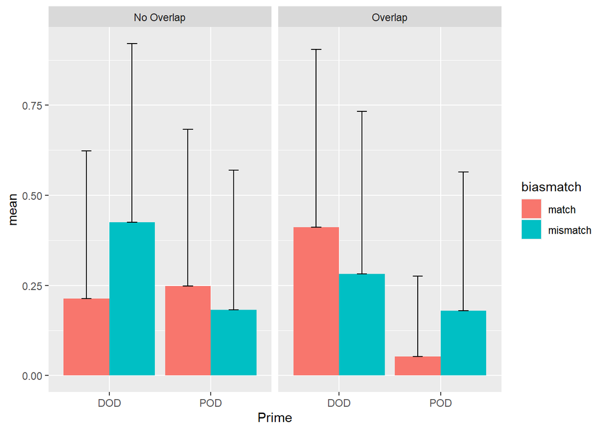

```r
XSectional %>%
  group_by(Prime, Overlap, biasmatch) %>%
  summarise(mean = mean(Response, na.rm=TRUE),
            sd = sd(Response, na.rm=TRUE)) %>%

ggplot(aes(y=mean, x=Prime, fill=biasmatch)) +
  geom_bar(stat="identity",position="dodge") +
 geom_errorbar(aes(ymin=mean, ymax=mean+sd), width=.2,
                 position=position_dodge(.9)) +
  facet_wrap(~Overlap)
```

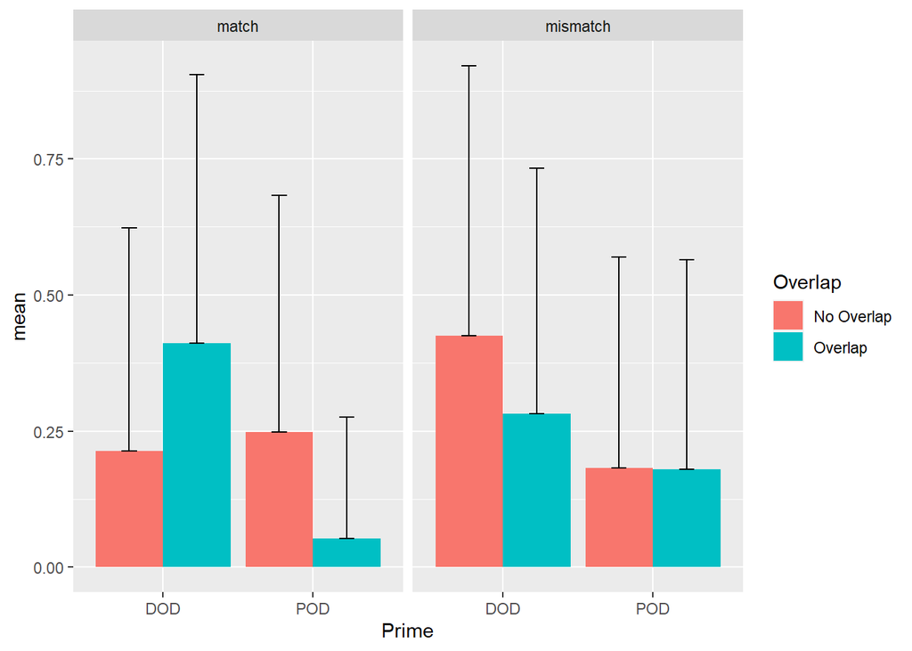

```r
XSectional %>%
  group_by(Prime, Overlap, biasmatch) %>%
  summarise(mean = mean(Response, na.rm=TRUE),
            sd = sd(Response, na.rm=TRUE)) %>%

ggplot(aes(y=mean, x=Prime, fill=Overlap)) +
  geom_bar(stat="identity",position="dodge") +
 geom_errorbar(aes(ymin=mean, ymax=mean+sd), width=.2,
                 position=position_dodge(.9)) +
  facet_wrap(~biasmatch)
```

## 1.3 Exploring the random effect structure.

Before getting to the substantive models, I fit several variance component models to determine an appropriate random effect structure. Note that because each participant responded to each verb twice, it is in principle possible to fit a model with random effects by participant, target verb and their interaction. I suspect this will greatly increase the estimation time, and will add a bunch of difficult to interpret parameters to the model. So I’m going to fit a a variance components model with and without this random factor, and compare the fit via loo.

```r
logit_prior = c(prior(normal(0,2), class=sd))
```

```r
m0 <- brm(Response ~ 1 + (1 | Case_ID) + (1 | Trial_verb) + (1 | Case_ID:Trial_verb), logit_prior, family="bernoulli", iter=4000, cores=4, data=XSectional, file="m0")
summary(m0)
```

```
##  Family: bernoulli
##   Links: mu = logit
## Formula: Response ~ 1 + (1 | Case_ID) + (1 | Trial_verb) + (1 | Case_ID:Trial_verb)
##    Data: XSectional (Number of observations: 1658)
## Samples: 4 chains, each with iter = 4000; warmup = 2000; thin = 1;
##          total post-warmup samples = 8000
##
## Group-Level Effects:
## ~Case_ID (Number of levels: 140)
##               Estimate Est.Error l-95% CI u-95% CI Rhat Bulk_ESS Tail_ESS
## sd(Intercept)     1.51      0.15     1.24     1.82 1.00     2405     3919
##
## ~Case_ID:Trial_verb (Number of levels: 838)
##               Estimate Est.Error l-95% CI u-95% CI Rhat Bulk_ESS Tail_ESS
## sd(Intercept)     0.20      0.15     0.01     0.55 1.00     1361     2511
##
## ~Trial_verb (Number of levels: 6)
##               Estimate Est.Error l-95% CI u-95% CI Rhat Bulk_ESS Tail_ESS
## sd(Intercept)     1.06      0.43     0.53     2.16 1.00     2259     3342
##
## Population-Level Effects:
##           Estimate Est.Error l-95% CI u-95% CI Rhat Bulk_ESS Tail_ESS
## Intercept    -1.55      0.46    -2.49    -0.62 1.00     1783     2766
##
## Samples were drawn using sampling(NUTS). For each parameter, Bulk_ESS
## and Tail_ESS are effective sample size measures, and Rhat is the potential
## scale reduction factor on split chains (at convergence, Rhat = 1).
```

Fit a simpler model without the interaction between participant and trial.

```r
m0b <- brm(Response ~ 1 + (1 | Case_ID) + (1 | Trial_verb), logit_prior, family="bernoulli", iter=4000, cores=4, data=XSectional, file="m0b")
summary(m0b)
```

```
##  Family: bernoulli
##   Links: mu = logit
## Formula: Response ~ 1 + (1 | Case_ID) + (1 | Trial_verb)
##    Data: XSectional (Number of observations: 1658)
## Samples: 4 chains, each with iter = 4000; warmup = 2000; thin = 1;
##          total post-warmup samples = 8000
##
## Group-Level Effects:
## ~Case_ID (Number of levels: 140)
##               Estimate Est.Error l-95% CI u-95% CI Rhat Bulk_ESS Tail_ESS
## sd(Intercept)     1.50      0.14     1.24     1.80 1.00     3044     4791
##
## ~Trial_verb (Number of levels: 6)
##               Estimate Est.Error l-95% CI u-95% CI Rhat Bulk_ESS Tail_ESS
## sd(Intercept)     1.05      0.42     0.53     2.13 1.00     2355     3639
##
## Population-Level Effects:
##           Estimate Est.Error l-95% CI u-95% CI Rhat Bulk_ESS Tail_ESS
## Intercept    -1.52      0.47    -2.37    -0.54 1.00     2053     2982
##
## Samples were drawn using sampling(NUTS). For each parameter, Bulk_ESS
## and Tail_ESS are effective sample size measures, and Rhat is the potential
## scale reduction factor on split chains (at convergence, Rhat = 1).
```

Add loo for loo_compare

```r
m0<- add_criterion(m0, "loo")
m0b<- add_criterion(m0b, "loo")
```

```r
loo(m0, m0b)
```

```
## Output of model 'm0':
##
## Computed from 8000 by 1658 log-likelihood matrix
##
##          Estimate   SE
## elpd_loo   -736.3 22.8
## p_loo       111.2  4.6
## looic      1472.6 45.7
## ------
## Monte Carlo SE of elpd_loo is 0.1.
##
## Pareto k diagnostic values:
##                          Count Pct.    Min. n_eff
## (-Inf, 0.5]   (good)     1655  99.8%   2496
##  (0.5, 0.7]   (ok)          3   0.2%   3413
##    (0.7, 1]   (bad)         0   0.0%   <NA>
##    (1, Inf)   (very bad)    0   0.0%   <NA>
##
## All Pareto k estimates are ok (k < 0.7).
## See help('pareto-k-diagnostic') for details.
##
## Output of model 'm0b':
##
## Computed from 8000 by 1658 log-likelihood matrix
##
##          Estimate   SE
## elpd_loo   -735.5 22.8
## p_loo       101.5  4.2
## looic      1470.9 45.6
## ------
## Monte Carlo SE of elpd_loo is 0.1.
##
## Pareto k diagnostic values:
##                          Count Pct.    Min. n_eff
## (-Inf, 0.5]   (good)     1654  99.8%   3761
##  (0.5, 0.7]   (ok)          4   0.2%   4843
##    (0.7, 1]   (bad)         0   0.0%   <NA>
##    (1, Inf)   (very bad)    0   0.0%   <NA>
##
## All Pareto k estimates are ok (k < 0.7).
## See help('pareto-k-diagnostic') for details.
##
## Model comparisons:
##     elpd_diff se_diff
## m0b  0.0       0.0
## m0  -0.9       0.4
```

```r
model_weights(m0, m0b)
```

```
##           m0          m0b
## 1.205362e-05 9.999879e-01
```

M0b is favored over m0 and this difference was greater than 2SE, so I think that given the added complexity of the part X item random effects isn’t adding anything, then it’s not worth the extra interpretational complexity when the other covariates are added.

I’m going to plot the random intercepts and the average number of double object datives produced by participant.

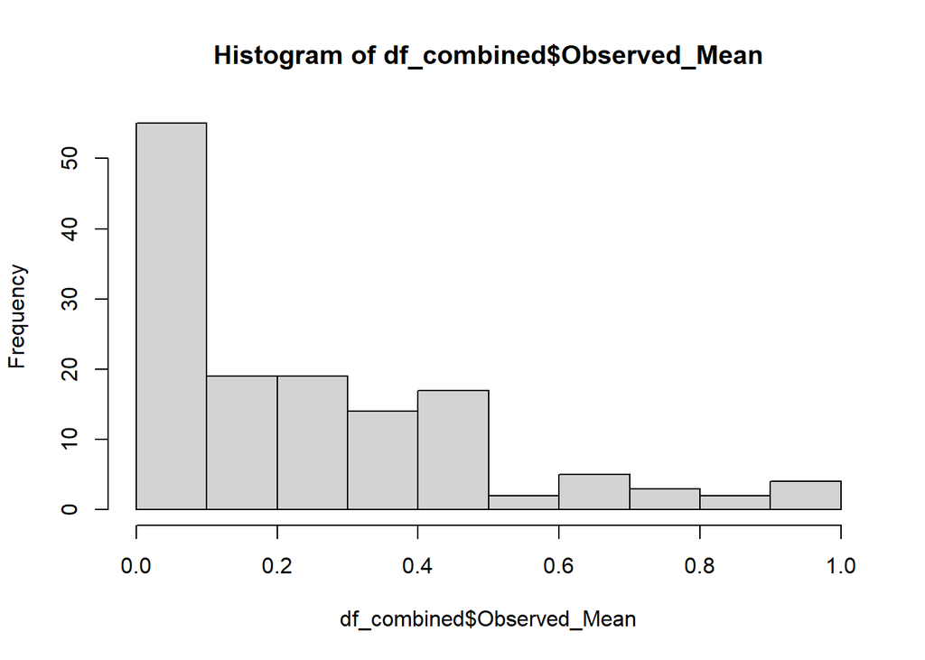

```r
df <- m0b %>%
  spread_draws(b_Intercept, r_Case_ID[Case_ID,Intercept])

df <- df %>%
  mutate(
    Part_Mean = inv_logit_scaled(b_Intercept + r_Case_ID)
  )

df_part <- df %>%
  group_by(Case_ID) %>%
  summarise(
    Predict_Mean = mean(Part_Mean),
    Predict_SD = sd(Part_Mean)
  )

df_raw_part <- XSectional %>%
  group_by(Case_ID) %>%
  summarise(
    Observed_Mean = mean(Response, na.rm=TRUE)
  )

df_combined <- merge(df_part, df_raw_part, by="Case_ID")

hist(df_combined$Observed_Mean)
```

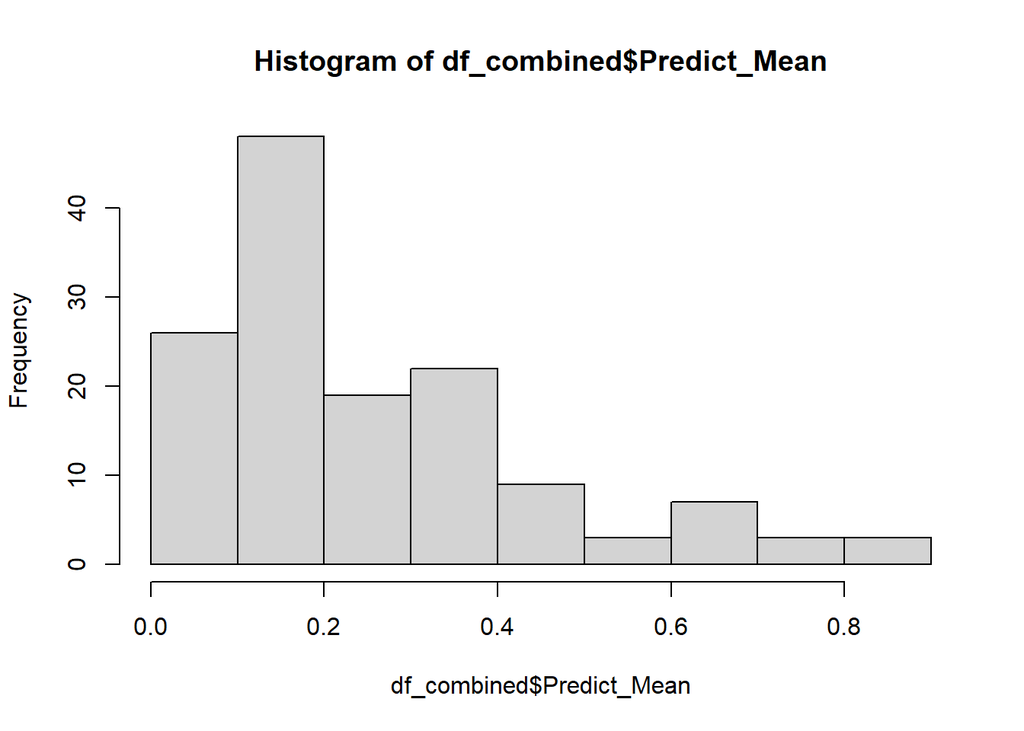

```r
hist(df_combined$Predict_Mean )
```

There are a lot of 0s because some children did not produce a single DoD in this task.

I’m going to make another data set for participants who produced at least 1 DoD, since a participant needs to have acquired a construction to be primed by it. This was also done in the Kumarage et al (Submitted) paper

```r
XSectional2 <- merge(XSectional, df_raw_part, by="Case_ID")
XSectional2 <- subset(XSectional2, Observed_Mean != 0)
```

# 2 Testing effects of lexical overlap

I’ve coded prime using effects coding and overlap using dummy coding. With this parameterization, the effect of prime tells me the priming effect in the non-overlap condition (i.e., the abstract priming effect), rather than the main effect. The interaction then tells us how this effect is moderated by lexical overlap.

## 2.1 Model on Full Sample.

```r
m1 <- brm(Response ~ 1 + Prime_type*Overlap*Agec + (1 + Prime_type*Overlap| Case_ID) + (1 + Prime_type*Overlap*Agec | Trial_verb), logit_prior, family="bernoulli", iter=4000, cores=4, save_all_pars=TRUE,  data=XSectional, file="m1")
summary(m1)
```

```
##  Family: bernoulli
##   Links: mu = logit
## Formula: Response ~ 1 + Prime_type * Overlap * Agec + (1 + Prime_type * Overlap | Case_ID) + (1 + Prime_type * Overlap * Agec | Trial_verb)
##    Data: XSectional (Number of observations: 1658)
## Samples: 4 chains, each with iter = 4000; warmup = 2000; thin = 1;
##          total post-warmup samples = 8000
##
## Group-Level Effects:
## ~Case_ID (Number of levels: 140)
##                                               Estimate Est.Error l-95% CI
## sd(Intercept)                                     1.72      0.20     1.36
## sd(Prime_type)                                    0.53      0.34     0.02
## sd(OverlapOverlap)                                0.40      0.27     0.02
## sd(Prime_type:OverlapOverlap)                     0.94      0.56     0.06
## cor(Intercept,Prime_type)                        -0.24      0.38    -0.84
## cor(Intercept,OverlapOverlap)                     0.30      0.40    -0.59
## cor(Prime_type,OverlapOverlap)                   -0.11      0.43    -0.85
## cor(Intercept,Prime_type:OverlapOverlap)         -0.13      0.35    -0.75
## cor(Prime_type,Prime_type:OverlapOverlap)         0.03      0.43    -0.79
## cor(OverlapOverlap,Prime_type:OverlapOverlap)    -0.11      0.44    -0.84
##                                               u-95% CI Rhat Bulk_ESS Tail_ESS
## sd(Intercept)                                     2.13 1.00     3434     5472
## sd(Prime_type)                                    1.27 1.00     2311     4268
## sd(OverlapOverlap)                                1.00 1.00     1870     4007
## sd(Prime_type:OverlapOverlap)                     2.10 1.00     1590     3581
## cor(Intercept,Prime_type)                         0.61 1.00     9312     5829
## cor(Intercept,OverlapOverlap)                     0.90 1.00     7563     5011
## cor(Prime_type,OverlapOverlap)                    0.73 1.00     4613     6189
## cor(Intercept,Prime_type:OverlapOverlap)          0.61 1.00     9283     5214
## cor(Prime_type,Prime_type:OverlapOverlap)         0.81 1.00     3918     4992
## cor(OverlapOverlap,Prime_type:OverlapOverlap)     0.73 1.00     3314     5878
##
## ~Trial_verb (Number of levels: 6)
##                                                               Estimate
## sd(Intercept)                                                     1.39
## sd(Prime_type)                                                    0.60
## sd(OverlapOverlap)                                                0.46
## sd(Agec)                                                          0.36
## sd(Prime_type:OverlapOverlap)                                     0.81
## sd(Prime_type:Agec)                                               0.23
```

[output cut: 187 more lines]

```
## OverlapOverlap:Agec                0.06      0.33    -0.59     0.75 1.00
## Prime_type:OverlapOverlap:Agec     0.07      0.37    -0.67     0.81 1.00
##                                Bulk_ESS Tail_ESS
## Intercept                          3725     4539
## Prime_type                         6209     4596
## OverlapOverlap                     5463     5498
## Agec                               4994     5153
## Prime_type:OverlapOverlap          5596     5273
## Prime_type:Agec                    9091     5615
## OverlapOverlap:Agec                5334     4422
## Prime_type:OverlapOverlap:Agec     8285     5648
##
## Samples were drawn using sampling(NUTS). For each parameter, Bulk_ESS
## and Tail_ESS are effective sample size measures, and Rhat is the potential
## scale reduction factor on split chains (at convergence, Rhat = 1).
```

```r
m1 <- add_criterion(m1, "loo")
```

### 2.1.1 Some diagnostics

Compare posterior predictive distribution to data.

```r
pp_check(m1)
```

```
## Using 10 posterior samples for ppc type 'dens_overlay' by default.
```

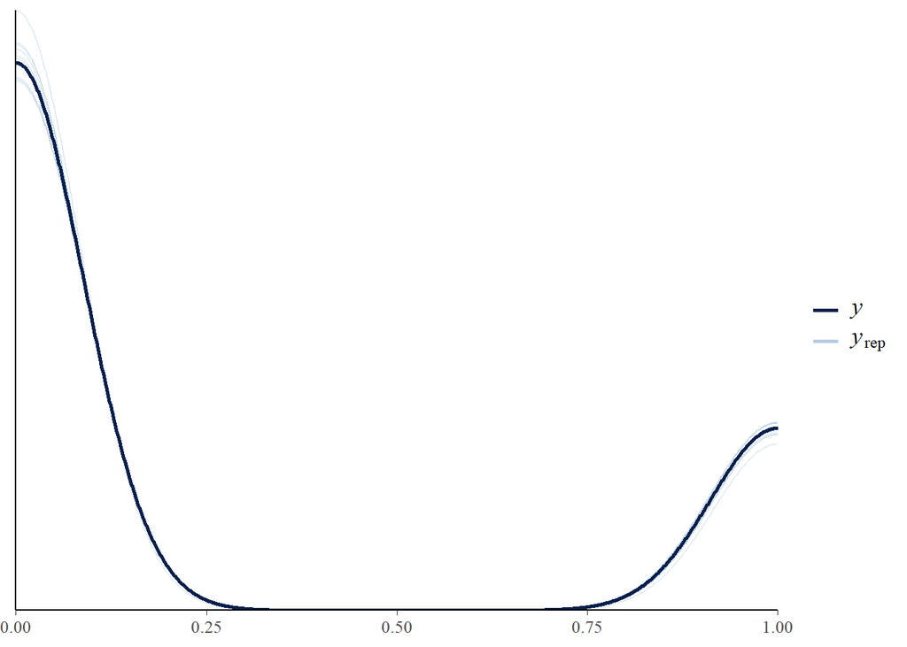

Looks good. I think we’re doing a pretty good job capturing the data.

Take a look at the distribution of Pareto’s k.

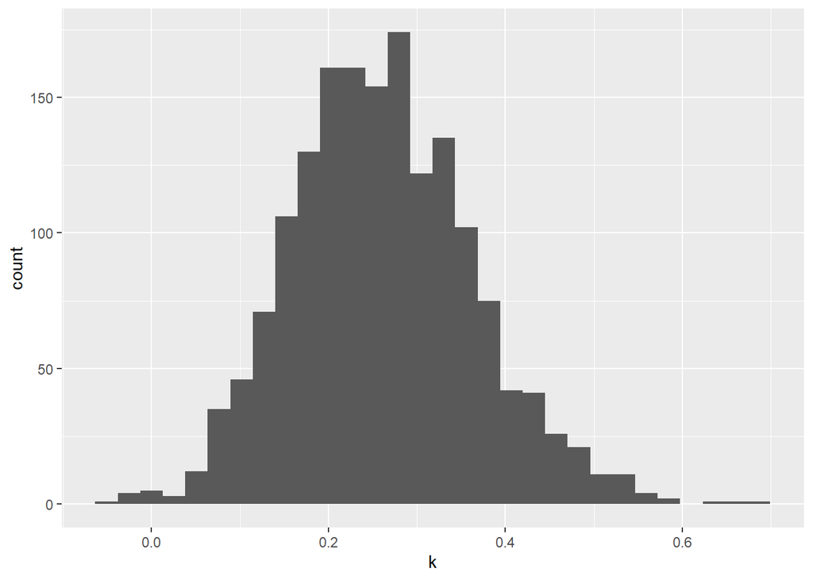

```r
XSectional %>%
  mutate(
    k = m1$criteria$loo$diagnostics$pareto_k
  ) %>%
  ggplot(aes(x=k)) + geom_histogram()
```

```r
XSectional %>%
  mutate(
    k = m1$criteria$loo$diagnostics$pareto_k
  ) %>%
  filter(k >= .7)
```

| Part_No | Case_ID | Gender | Age | List | Item | Prime_verb | Trial_verb | Prime_type | Verb_match | Response | Ravens | PPVT | Notes | drop | part_drop | trial_drop | Admin.Error | Verb.error | Non.allowable.prompt | Non.Target.Response | Attentiveness | Prime | Overlap | Agec | bias | Bias_POD | biasmatch | biasmismatchc | k |
| --- | --- | --- | --- | --- | --- | --- | --- | --- | --- | --- | --- | --- | --- | --- | --- | --- | --- | --- | --- | --- | --- | --- | --- | --- | --- | --- | --- | --- | --- |

A couple high-ish ones, though nothing above .7.

### 2.1.2 Inferences

Caclulate the proportion of the posterior distribution in each direction.

```r
hypothesis(m1, "Prime_type > 0")
```

```
## Hypothesis Tests for class b:
##         Hypothesis Estimate Est.Error CI.Lower CI.Upper Evid.Ratio Post.Prob
## 1 (Prime_type) > 0     1.06      0.39     0.47     1.72     149.94      0.99
##   Star
## 1    *
## ---
## 'CI': 90%-CI for one-sided and 95%-CI for two-sided hypotheses.
## '*': For one-sided hypotheses, the posterior probability exceeds 95%;
## for two-sided hypotheses, the value tested against lies outside the 95%-CI.
## Posterior probabilities of point hypotheses assume equal prior probabilities.
```

```r
hypothesis(m1, "Prime_type:OverlapOverlap > 0")
```

```
## Hypothesis Tests for class b:
##                 Hypothesis Estimate Est.Error CI.Lower CI.Upper Evid.Ratio
## 1 (Prime_type:Overl... > 0     1.63      0.61     0.69     2.67        159
##   Post.Prob Star
## 1      0.99    *
## ---
## 'CI': 90%-CI for one-sided and 95%-CI for two-sided hypotheses.
## '*': For one-sided hypotheses, the posterior probability exceeds 95%;
## for two-sided hypotheses, the value tested against lies outside the 95%-CI.
## Posterior probabilities of point hypotheses assume equal prior probabilities.
```

```r
hypothesis(m1, "Prime_type:Agec < 0")
```

```
## Hypothesis Tests for class b:
##              Hypothesis Estimate Est.Error CI.Lower CI.Upper Evid.Ratio
## 1 (Prime_type:Agec) < 0    -0.19      0.22    -0.55     0.16       4.81
##   Post.Prob Star
## 1      0.83
## ---
## 'CI': 90%-CI for one-sided and 95%-CI for two-sided hypotheses.
## '*': For one-sided hypotheses, the posterior probability exceeds 95%;
## for two-sided hypotheses, the value tested against lies outside the 95%-CI.
## Posterior probabilities of point hypotheses assume equal prior probabilities.
```

```r
hypothesis(m1, "Prime_type:OverlapOverlap:Agec > 0")
```

```
## Hypothesis Tests for class b:
##                 Hypothesis Estimate Est.Error CI.Lower CI.Upper Evid.Ratio
## 1 (Prime_type:Overl... > 0     0.07      0.37    -0.51     0.66       1.36
##   Post.Prob Star
## 1      0.58
## ---
## 'CI': 90%-CI for one-sided and 95%-CI for two-sided hypotheses.
## '*': For one-sided hypotheses, the posterior probability exceeds 95%;
## for two-sided hypotheses, the value tested against lies outside the 95%-CI.
## Posterior probabilities of point hypotheses assume equal prior probabilities.
```

Strong evidence for lexical boost, less evidence for interaction between lexical boost and age, or priming effect and age.

Plot fitted values on both logit and probability scale to understand the model. First I need to calculated means and CIs from the data to include in plots with the model estimates.

```r
library(plotrix)
means <- XSectional %>%
  mutate(
    Age_dis = round(Age, 0),
    Age_dis = ifelse(Age_dis == 3, yes=4, no = ifelse( # add the < 3.5 to 4 (only 1 kid)
      Age_dis ==9, yes=8, no= Age_dis  # add the > 8.5 to 9 (only 1 kid)
    ))
  ) %>%
  group_by(Part_No, Prime_type, Verb_match) %>%
  mutate(
    prop = mean(Response)
  ) %>%
  slice(1) %>%
  group_by(Age_dis, Prime, Overlap) %>%
  mutate(
    Prop2 = mean(prop),
    PropSE = std.error(prop, na.rm=TRUE),
  ) %>%
  slice(1) %>%
  dplyr::select(Age_dis, Prime, Overlap, Prop2, PropSE) %>%
  rename(Age = Age_dis, Estimate=Prop2) %>%
  mutate(
  CI = PropSE*1.92
  )

XSectional %>%
   mutate(
    Age_dis = round(Age, 0),
    Age_dis = ifelse(Age_dis == 3, yes=4, no = ifelse( # add the < 3.5 to 4 (only 1 kid)
      Age_dis ==9, yes=8, no= Age_dis  # add the > 8.5 to 9 (only 1 kid)
    ))
  ) %>%
  group_by(Part_No) %>%
  slice(1) %>%
  ungroup() %>%
  group_by(Age_dis) %>%
  count()
```

| Age_dis | n |
| --- | --- |
| 4 | 22 |
| 5 | 34 |
| 6 | 28 |
| 7 | 37 |
| 8 | 19 |

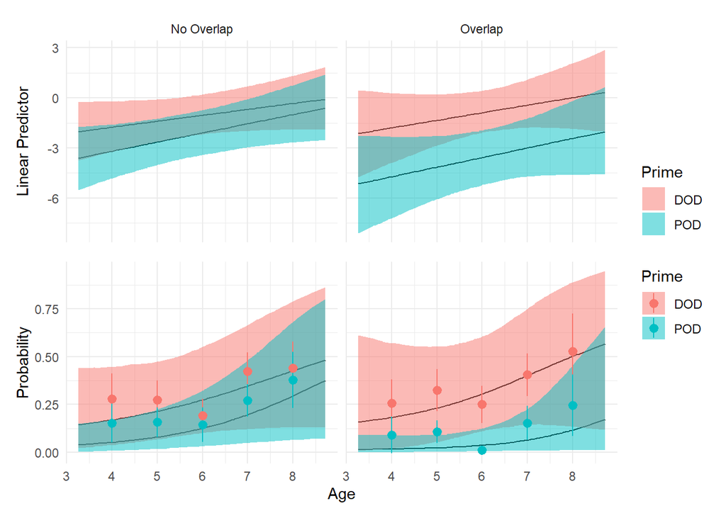

```r
m1_fitted_logit <- fitted(m1, re_formula=NA, scale="linear") %>%
  cbind(XSectional) %>%
  dplyr::select(Age, Prime, Overlap, Estimate, Q2.5, Q97.5) %>%
  ggplot(aes(y=Estimate, ymin=Q2.5, ymax=Q97.5, x=Age, fill=Prime, line=Prime)) +
  geom_line() +
  geom_ribbon(alpha=0.5) +
  theme_minimal() +
  labs(y="Linear Predictor") +
  theme(axis.title.x=element_blank(),
        axis.text.x=element_blank(),
        axis.ticks.x=element_blank(),
        legend.position = "none") +
facet_wrap(~Overlap)

m1_fitted_response <- fitted(m1, re_formula=NA, scale="response") %>%
  cbind(XSectional) %>%
  dplyr::select(Age, Prime, Overlap, Estimate, Q2.5, Q97.5) %>%
ggplot(aes(y=Estimate, ymin=Q2.5, ymax=Q97.5, x=Age, fill=Prime, line=Prime)) +
  geom_line() +
  geom_ribbon(alpha=0.5) +
   theme_minimal() +
  facet_wrap(~Overlap) +
  labs(y="Probability")  +
theme(
 strip.text.x = element_blank(),
 strip.background = element_blank()
)  +
geom_pointrange(data= means, aes(y=Estimate, x=Age, colour=Prime, max = Estimate + CI, min=Estimate-CI)) +
facet_wrap(~Overlap)



m1_fitted_logit/m1_fitted_response + plot_layout(guides = "collect") & theme(legend.position = "right")
```

```r
ggsave("plots/Fig2.png", last_plot(), dpi=500)
```

The priming effect and lexical boost are clear. It looks like there is an interaction between age and priming but the evidence for this effect is not compelling (posterior probability = .83). This is more visible on the logit scale.

Log odds are notoriously difficult to interpret, often a better way of quantifying the magnitude of an effect is a risk ratio. *CHECK THAT THIS IS CORRECT*

```r
library("tidybayes")
ps_means1 <- posterior_samples(m1) %>%
  dplyr::select(Intc = "b_Intercept", Prime = "b_Prime_type", Overlap= "b_OverlapOverlap", Int = "b_Prime_type:OverlapOverlap") %>%
  mutate(
    DOD_no = inv_logit_scaled(Intc + .5*Prime),
    POD_no = inv_logit_scaled(Intc  - .5*Prime),
    RR_ap = DOD_no/POD_no,
    DOD_o = inv_logit_scaled(Intc + .5*Prime + Overlap + .5*Int),
    POD_o = inv_logit_scaled(Intc - .5*Prime + Overlap - .5*Int),
    RR_ov = (DOD_o/POD_o)
  ) %>%
  dplyr::select(RR_ap, RR_ov) %>%
  pivot_longer(everything(), names_to = "RR", values_to = "value") %>%
  mutate(
    Effect = ifelse(RR=="RR_ap", yes= "Abstract Priming", no="Lexically Boosted Priming")
  )

ps_means1 %>%
  group_by(Effect) %>%
  dplyr::select(-"RR") %>%
  mean_hdi()
```

| Effect | value | .lower | .upper | .width | .point | .interval |
| --- | --- | --- | --- | --- | --- | --- |
| Abstract Priming | 2.523245 | 1.090407 | 4.477238 | 0.95 | mean | hdi |
| Lexically Boosted Priming | 12.973045 | 1.460276 | 30.182860 | 0.95 | mean | hdi |

```r
RR1 <- ggplot(ps_means1, aes(x=value, fill=Effect)) + geom_density(alpha = .2) + xlim(0, 15) + geom_vline(xintercept=1) + theme_minimal() + xlab("RR")
```

RRs for each time window

```r
df <- tibble(
  Overlap = factor(rep(c(0, 0, 1, 1), 5), labels = c("No Overlap", "Overlap")),
  Prime_type = rep(c(-.5, .5, -.5, .5), 5),
  Agec = c(-2, -2, -2, -2, -1, -1, -1, -1, 0, 0, 0, 0, 1, 1, 1, 1, 2, 2, 2, 2)
)

ps_means2 <- posterior_linpred(m1, newdata=df, re_formula=NA, scale="response") %>%
  t() %>%
  as_tibble() %>%
  bind_cols(df, .) %>%
  pivot_longer(starts_with("V"), names_to="sample", values_to="linpred") %>%
  mutate(
    prob = inv_logit_scaled(linpred)
  ) %>%
  mutate(
    Age = Agec + 6,
    Prime_type = ifelse(Prime_type == .5, yes="DOD", no = "POD"),
    Overlap = ifelse(Overlap=="Overlap", yes="Ov", no = "No")
  ) %>%
  dplyr::select(-c("linpred", "Agec")) %>%
  pivot_wider(names_from=c("Overlap", "Prime_type", "Age"), values_from="prob") %>%
  mutate(
    Abstract_4 = No_DOD_4/No_POD_4,
    LB_4 = Ov_DOD_4/Ov_POD_4,
    Abstract_5 = No_DOD_5/No_POD_5,
    LB_5 = Ov_DOD_5/Ov_POD_5,
    Abstract_6 = No_DOD_6/No_POD_6,
    LB_6 = Ov_DOD_6/Ov_POD_6,
    Abstract_7 = No_DOD_7/No_POD_7,
    LB_7 = Ov_DOD_7/Ov_POD_7,
    Abstract_8 = No_DOD_8/No_POD_8,
    LB_8 = Ov_DOD_8/Ov_POD_8
  ) %>%
  dplyr::select("sample", starts_with(c("Abs", "LB"))) %>%
  pivot_longer(
    starts_with(c("Abs", "LB")),
    names_to = c("Effect", "Age"),
    names_sep = "_",
    values_to = "RR"
  ) %>%
  mutate(
    Effect = ifelse(Effect=="Abstract", yes= "Abstract Priming", no = "Lexically Boosted n/Priming")
  ) %>%
  filter(Age != "6") # redunant wiht other graph
ps_means2 %>%
  dplyr::select(-"sample") %>%
  group_by(Age, Effect) %>%
  mean_hdi()
```

| Age | Effect | RR | .lower | .upper | .width | .point | .interval |
| --- | --- | --- | --- | --- | --- | --- | --- |
| 4 | Abstract Priming | 4.447314 | 0.6236120 | 9.630793 | 0.95 | mean | hdi |
| 4 | Lexically Boosted n/Priming | 27.072965 | 0.3061248 | 76.128753 | 0.95 | mean | hdi |
| 5 | Abstract Priming | 3.273276 | 0.9103228 | 6.267628 | 0.95 | mean | hdi |
| 5 | Lexically Boosted n/Priming | 17.606209 | 1.1426868 | 44.668874 | 0.95 | mean | hdi |
| 7 | Abstract Priming | 2.025761 | 0.8863234 | 3.554142 | 0.95 | mean | hdi |
| 7 | Lexically Boosted n/Priming | 10.202238 | 1.0659961 | 24.269048 | 0.95 | mean | hdi |
| 8 | Abstract Priming | 1.692400 | 0.6214611 | 3.186369 | 0.95 | mean | hdi |
| 8 | Lexically Boosted n/Priming | 8.489241 | 0.5951964 | 22.930579 | 0.95 | mean | hdi |

```r
RR2 <- ggplot(ps_means2,aes(x=RR, fill=Effect)) + geom_density(alpha=.2) + facet_grid(Age ~ .) + xlim(0, 15) + theme_minimal() + geom_vline(xintercept=1) + theme_minimal()
```

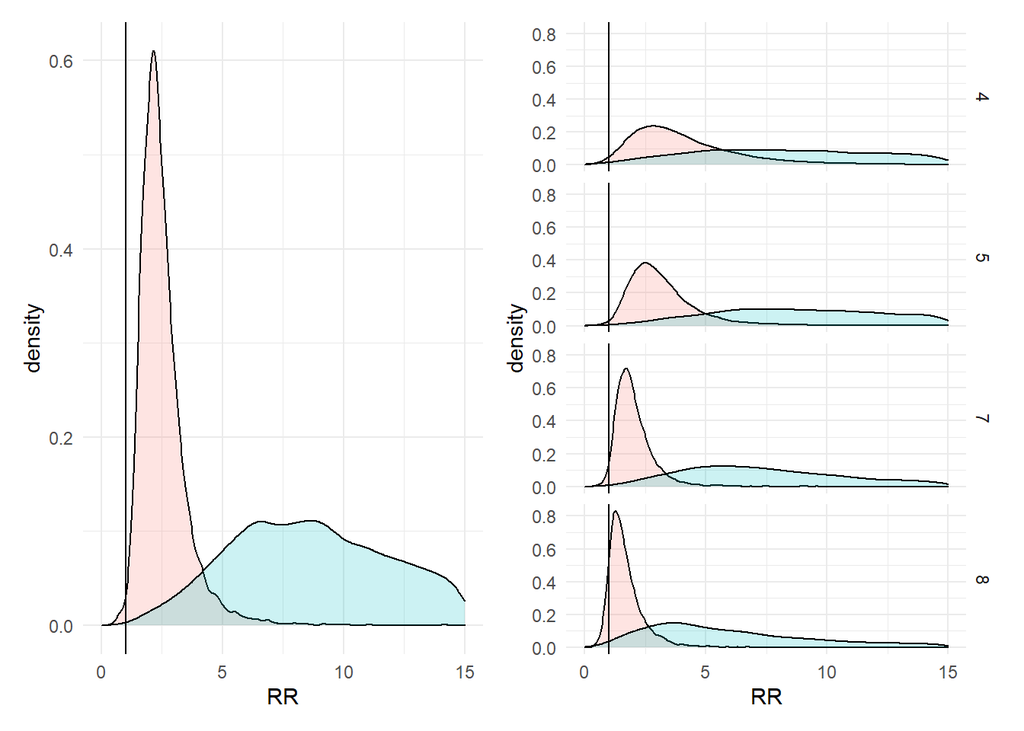

```r
RR1 + RR2 +  plot_layout(guides = "collect") & theme(legend.position = "none")
```

```r
ggsave("plots/Fig3.png", last_plot(), dpi=500)
```

I’ll note that the posterior distribution for the each of those conditions effects are really wide – this might be because the model isn’t finding much of an interaction and the credible intervals for the three way interaction are quite larger relative to the magnitude of the effect, so I think including this interaction in the calculation of all of the relevant conditional effects is adding a great deal of extra uncertainty.

### 2.1.3 Simplify the random effects structure

Note that in the model above, I included correlated random effects. It took forever to run, and I essentially got the prior back for most of those correlations (modes of 0 with really large errors). I’m going to fit the model again with uncorrelated random effects, to make sure I get comparable results–in other words I want to make sure that all the uncertainty I’m adding to the mode isn’t affecting the posterior distributions for other parameters. UPDATE: We get roughly the same results. I’ve suppressed the output from these models in this HTML file, but the code is in the R Markdown file for those interested.

## 2.2 Only participants who produced at least 1 DOD.

Now I’ll re-fit the model on the participants who produced at least 1 DOD.

```r
m2 <- brm(Response ~ 1 + Prime_type*Overlap*Agec + (1 + Prime_type*Overlap| Case_ID) + (1 + Prime_type*Overlap*Agec | Trial_verb), logit_prior, family="bernoulli", iter=4000, cores=4, save_all_pars=TRUE,  data=XSectional2, file="m2")
summary(m2)
```

```
##  Family: bernoulli
##   Links: mu = logit
## Formula: Response ~ 1 + Prime_type * Overlap * Agec + (1 + Prime_type * Overlap | Case_ID) + (1 + Prime_type * Overlap * Agec | Trial_verb)
##    Data: XSectional2 (Number of observations: 1348)
## Samples: 4 chains, each with iter = 4000; warmup = 2000; thin = 1;
##          total post-warmup samples = 8000
##
## Group-Level Effects:
## ~Case_ID (Number of levels: 114)
##                                               Estimate Est.Error l-95% CI
## sd(Intercept)                                     1.29      0.17     0.97
## sd(Prime_type)                                    0.59      0.35     0.03
## sd(OverlapOverlap)                                0.43      0.27     0.02
## sd(Prime_type:OverlapOverlap)                     0.98      0.57     0.05
## cor(Intercept,Prime_type)                        -0.35      0.36    -0.88
## cor(Intercept,OverlapOverlap)                     0.32      0.38    -0.54
## cor(Prime_type,OverlapOverlap)                   -0.17      0.42    -0.85
## cor(Intercept,Prime_type:OverlapOverlap)         -0.23      0.35    -0.80
## cor(Prime_type,Prime_type:OverlapOverlap)         0.08      0.42    -0.73
## cor(OverlapOverlap,Prime_type:OverlapOverlap)    -0.14      0.43    -0.86
##                                               u-95% CI Rhat Bulk_ESS Tail_ESS
## sd(Intercept)                                     1.63 1.00     3725     5337
## sd(Prime_type)                                    1.31 1.00     2562     3701
## sd(OverlapOverlap)                                1.01 1.00     1796     3068
## sd(Prime_type:OverlapOverlap)                     2.16 1.00     1675     3310
## cor(Intercept,Prime_type)                         0.52 1.00     7344     5210
## cor(Intercept,OverlapOverlap)                     0.89 1.00     7120     5083
## cor(Prime_type,OverlapOverlap)                    0.71 1.00     4410     5686
## cor(Intercept,Prime_type:OverlapOverlap)          0.56 1.00     8082     5506
## cor(Prime_type,Prime_type:OverlapOverlap)         0.82 1.00     3908     4886
## cor(OverlapOverlap,Prime_type:OverlapOverlap)     0.75 1.00     3519     5522
##
## ~Trial_verb (Number of levels: 6)
##                                                               Estimate
## sd(Intercept)                                                     1.38
## sd(Prime_type)                                                    0.64
## sd(OverlapOverlap)                                                0.45
## sd(Agec)                                                          0.37
## sd(Prime_type:OverlapOverlap)                                     0.77
## sd(Prime_type:Agec)                                               0.23
```

[output cut: 187 more lines]

```
## OverlapOverlap:Agec                0.05      0.35    -0.63     0.74 1.00
## Prime_type:OverlapOverlap:Agec     0.04      0.38    -0.71     0.76 1.00
##                                Bulk_ESS Tail_ESS
## Intercept                          3499     4646
## Prime_type                         6230     5285
## OverlapOverlap                     5162     4992
## Agec                               5735     5455
## Prime_type:OverlapOverlap          5025     5431
## Prime_type:Agec                    7129     4848
## OverlapOverlap:Agec                5785     4847
## Prime_type:OverlapOverlap:Agec     7300     5470
##
## Samples were drawn using sampling(NUTS). For each parameter, Bulk_ESS
## and Tail_ESS are effective sample size measures, and Rhat is the potential
## scale reduction factor on split chains (at convergence, Rhat = 1).
```

```r
m2 <- add_criterion(m2, "loo")
```

```r
hypothesis(m2, "Prime_type > 0")
```

```
## Hypothesis Tests for class b:
##         Hypothesis Estimate Est.Error CI.Lower CI.Upper Evid.Ratio Post.Prob
## 1 (Prime_type) > 0     1.06       0.4     0.46     1.71     139.35      0.99
##   Star
## 1    *
## ---
## 'CI': 90%-CI for one-sided and 95%-CI for two-sided hypotheses.
## '*': For one-sided hypotheses, the posterior probability exceeds 95%;
## for two-sided hypotheses, the value tested against lies outside the 95%-CI.
## Posterior probabilities of point hypotheses assume equal prior probabilities.
```

```r
hypothesis(m2, "Prime_type:OverlapOverlap > 0")
```

```
## Hypothesis Tests for class b:
##                 Hypothesis Estimate Est.Error CI.Lower CI.Upper Evid.Ratio
## 1 (Prime_type:Overl... > 0     1.67      0.58      0.8     2.65        399
##   Post.Prob Star
## 1         1    *
## ---
## 'CI': 90%-CI for one-sided and 95%-CI for two-sided hypotheses.
## '*': For one-sided hypotheses, the posterior probability exceeds 95%;
## for two-sided hypotheses, the value tested against lies outside the 95%-CI.
## Posterior probabilities of point hypotheses assume equal prior probabilities.
```

```r
hypothesis(m2, "Prime_type:Agec < 0")
```

```
## Hypothesis Tests for class b:
##              Hypothesis Estimate Est.Error CI.Lower CI.Upper Evid.Ratio
## 1 (Prime_type:Agec) < 0     -0.2      0.23    -0.55     0.15       5.05
##   Post.Prob Star
## 1      0.83
## ---
## 'CI': 90%-CI for one-sided and 95%-CI for two-sided hypotheses.
## '*': For one-sided hypotheses, the posterior probability exceeds 95%;
## for two-sided hypotheses, the value tested against lies outside the 95%-CI.
## Posterior probabilities of point hypotheses assume equal prior probabilities.
```

```r
hypothesis(m2, "Prime_type:OverlapOverlap:Agec > 0")
```

```
## Hypothesis Tests for class b:
##                 Hypothesis Estimate Est.Error CI.Lower CI.Upper Evid.Ratio
## 1 (Prime_type:Overl... > 0     0.04      0.38    -0.56     0.63       1.17
##   Post.Prob Star
## 1      0.54
## ---
## 'CI': 90%-CI for one-sided and 95%-CI for two-sided hypotheses.
## '*': For one-sided hypotheses, the posterior probability exceeds 95%;
## for two-sided hypotheses, the value tested against lies outside the 95%-CI.
## Posterior probabilities of point hypotheses assume equal prior probabilities.
```

We get pretty much the same pattern: clear lexical boost and clear priming, but no effect of age on the priming effect or the lexical boost.

I’m going to make similar plots as before. I’ve not included most of the code so as to maintain readability of this file

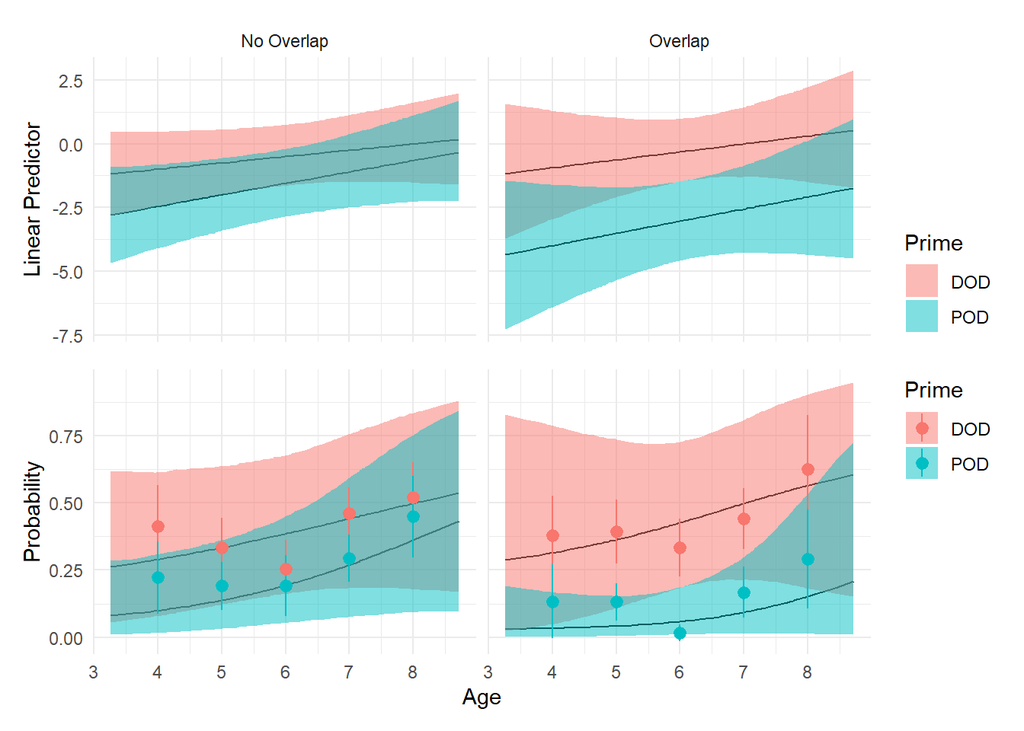

Plots of model predicted values look pretty similar– thought it looks like something weird is happening with the 6 year olds.

| Effect | value | .lower | .upper | .width | .point | .interval |
| --- | --- | --- | --- | --- | --- | --- |
| Abstract Priming | 2.286868 | 1.052314 | 3.980391 | 0.95 | mean | hdi |
| Lexically Boosted Priming | 10.891495 | 1.922179 | 25.603188 | 0.95 | mean | hdi |

```r
df <- tibble(
  Overlap = factor(rep(c(0, 0, 1, 1), 5), labels = c("No Overlap", "Overlap")),
  Prime_type = rep(c(-.5, .5, -.5, .5), 5),
  Agec = c(-2, -2, -2, -2, -1, -1, -1, -1, 0, 0, 0, 0, 1, 1, 1, 1, 2, 2, 2, 2)
)

ps_means4 <- posterior_linpred(m2, newdata=df, re_formula=NA, scale="response") %>%
  t() %>%
  as_tibble() %>%
  bind_cols(df, .) %>%
  pivot_longer(starts_with("V"), names_to="sample", values_to="linpred") %>%
  mutate(
    prob = inv_logit_scaled(linpred)
  ) %>%
  mutate(
    Age = Agec + 6,
    Prime_type = ifelse(Prime_type == .5, yes="DOD", no = "POD"),
    Overlap = ifelse(Overlap=="Overlap", yes="Ov", no = "No")
  ) %>%
  dplyr::select(-c("linpred", "Agec")) %>%
  pivot_wider(names_from=c("Overlap", "Prime_type", "Age"), values_from="prob") %>%
  mutate(
    Abstract_4 = No_DOD_4/No_POD_4,
    LB_4 = (Ov_DOD_4/Ov_POD_4),
    Abstract_5 = No_DOD_5/No_POD_5,
    LB_5 = (Ov_DOD_5/Ov_POD_5),
    Abstract_6 = No_DOD_6/No_POD_6,
    LB_6 = (Ov_DOD_6/Ov_POD_6),
    Abstract_7 = No_DOD_7/No_POD_7,
    LB_7 = (Ov_DOD_7/Ov_POD_7),
    Abstract_8 = No_DOD_8/No_POD_8,
    LB_8 = (Ov_DOD_8/Ov_POD_8),
  ) %>%
  dplyr::select("sample", starts_with(c("Abs", "LB"))) %>%
  pivot_longer(
    starts_with(c("Abs", "LB")),
    names_to = c("Effect", "Age"),
    names_sep = "_",
    values_to = "RR"
  ) %>%
  mutate(
    Effect = ifelse(Effect=="Abstract", yes= "Abstract Priming", no = "Lexically Boosted Priming")
  ) %>%
  filter(
    Age != "6"
  )

ps_means4 %>%
  dplyr::select(-"sample") %>%
  group_by(Age, Effect) %>%
  mean_hdi()
```

[output not shown]

```r
RR4 <- ggplot(ps_means4, aes(x=RR, fill=Effect)) + geom_density(alpha=.2) + facet_grid(Age ~ .) + xlim(0, 10) + theme_minimal() + geom_vline(xintercept=1) + theme_minimal()
```

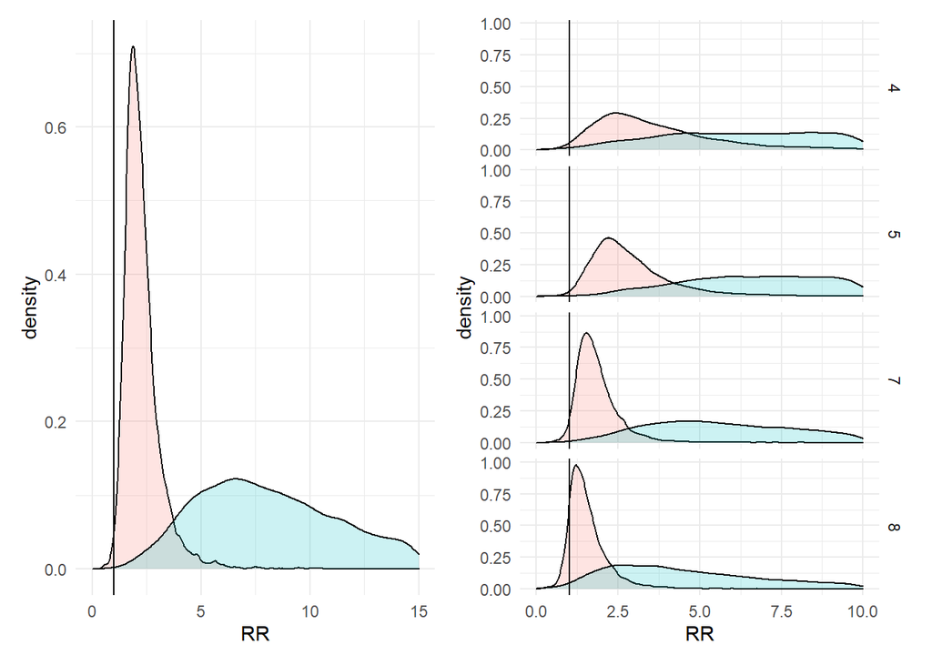

```r
RR3 + RR4 +  plot_layout(guides = "collect") & theme(legend.position = "none")
```

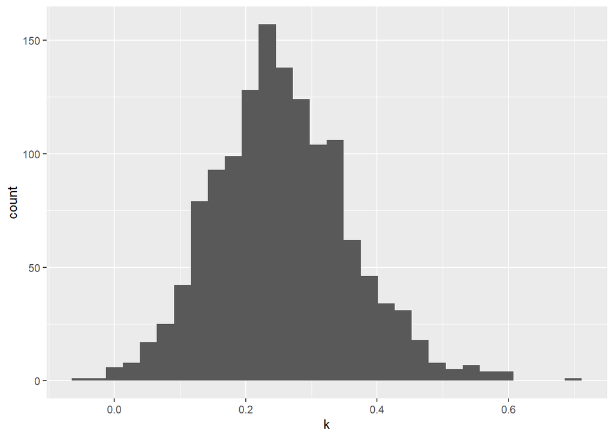

```r
ggsave("plots/Fig5.png", last_plot(), dpi=500)
# One of the pareto k values was exactly .7. I've re-fit the model without that observation. Nothing important changed, but here is the code for estimating this model.
XSectional2 %>%
  mutate(
    k = m2$criteria$loo$diagnostics$pareto_k
  ) %>%
ggplot(aes(x=k)) + geom_histogram()
```

```r
XSectional2 %>%
  mutate(
    k = m2$criteria$loo$diagnostics$pareto_k
  ) %>%
  filter(k < .7) %>%
brm(Response ~ 1 + Prime_type*Overlap*Agec + (1 + Prime_type*Overlap| Case_ID) + (1 + Prime_type*Overlap*Agec | Trial_verb), prior=logit_prior, family="bernoulli", iter=4000, cores=4, save_all_pars=TRUE,  data=., file="m2_no_low_k") %>%
summary()
```

```
##  Family: bernoulli
##   Links: mu = logit
## Formula: Response ~ 1 + Prime_type * Overlap * Agec + (1 + Prime_type * Overlap | Case_ID) + (1 + Prime_type * Overlap * Agec | Trial_verb)
##    Data: . (Number of observations: 1348)
## Samples: 4 chains, each with iter = 4000; warmup = 2000; thin = 1;
##          total post-warmup samples = 8000
##
## Group-Level Effects:
## ~Case_ID (Number of levels: 114)
##                                               Estimate Est.Error l-95% CI
## sd(Intercept)                                     1.29      0.17     0.98
## sd(Prime_type)                                    0.59      0.35     0.04
## sd(OverlapOverlap)                                0.43      0.27     0.02
## sd(Prime_type:OverlapOverlap)                     0.97      0.56     0.06
## cor(Intercept,Prime_type)                        -0.35      0.35    -0.88
## cor(Intercept,OverlapOverlap)                     0.32      0.38    -0.56
## cor(Prime_type,OverlapOverlap)                   -0.17      0.42    -0.86
## cor(Intercept,Prime_type:OverlapOverlap)         -0.23      0.35    -0.82
## cor(Prime_type,Prime_type:OverlapOverlap)         0.07      0.43    -0.75
## cor(OverlapOverlap,Prime_type:OverlapOverlap)    -0.15      0.43    -0.86
##                                               u-95% CI Rhat Bulk_ESS Tail_ESS
## sd(Intercept)                                     1.64 1.00     3160     5645
## sd(Prime_type)                                    1.34 1.00     2112     3276
## sd(OverlapOverlap)                                1.02 1.01     1704     3742
## sd(Prime_type:OverlapOverlap)                     2.13 1.00     1608     3174
## cor(Intercept,Prime_type)                         0.50 1.00     6815     4626
## cor(Intercept,OverlapOverlap)                     0.89 1.00     7368     5851
## cor(Prime_type,OverlapOverlap)                    0.70 1.00     4233     5979
## cor(Intercept,Prime_type:OverlapOverlap)          0.56 1.00     7998     5598
## cor(Prime_type,Prime_type:OverlapOverlap)         0.82 1.00     3238     4724
## cor(OverlapOverlap,Prime_type:OverlapOverlap)     0.75 1.00     3694     5694
##
## ~Trial_verb (Number of levels: 6)
##                                                               Estimate
## sd(Intercept)                                                     1.39
## sd(Prime_type)                                                    0.67
## sd(OverlapOverlap)                                                0.45
## sd(Agec)                                                          0.35
## sd(Prime_type:OverlapOverlap)                                     0.75
## sd(Prime_type:Agec)                                               0.22
```

[output cut: 187 more lines]

```
## OverlapOverlap:Agec                0.05      0.34    -0.63     0.75 1.00
## Prime_type:OverlapOverlap:Agec     0.04      0.37    -0.68     0.78 1.00
##                                Bulk_ESS Tail_ESS
## Intercept                          2978     4069
## Prime_type                         4886     4318
## OverlapOverlap                     4213     5769
## Agec                               5067     5202
## Prime_type:OverlapOverlap          5903     4986
## Prime_type:Agec                    9111     5646
## OverlapOverlap:Agec                5273     4769
## Prime_type:OverlapOverlap:Agec     7728     5901
##
## Samples were drawn using sampling(NUTS). For each parameter, Bulk_ESS
## and Tail_ESS are effective sample size measures, and Rhat is the potential
## scale reduction factor on split chains (at convergence, Rhat = 1).
```

## 2.3 Table with models.

APA Style table with parameters of the model.

```r
tab_model(m1, m2, show.re.var=FALSE, show.r2=FALSE, show.icc=FALSE, transform=NULL, collapse.ci=TRUE, p.style="scientific", ci.hyphen = " : ", dv.labels=c("Model 1",  "Model 2"), string.stat="",
          pred.labels=c(
            "Intercept",
            "Prime (DOD)",
            "Overlap",
            "Age.c",
            "Prime * Overlap",
            "Prime * Age.c",
            "Overlap * Age.c",
            "Prime * Overlap * Age.c"
          ))
```

|  | Model 1 | Model 2 |
| --- | --- | --- |
| Predictors | Log-Odds | Log-Odds |
| Intercept | -1.60 (-2.76 : -0.34) | -1.05 (-2.20 : 0.21) |
| Prime (DOD) | 1.04 (0.32 : 1.89) | 1.04 (0.30 : 1.90) |
| Overlap | -0.66 (-1.32 : -0.01) | -0.65 (-1.27 : -0.02) |
| Age.c | 0.45 (0.00 : 0.91) | 0.35 (-0.08 : 0.78) |
| Prime * Overlap | 1.60 (0.48 : 2.93) | 1.64 (0.61 : 2.90) |
| Prime * Age.c | -0.19 (-0.64 : 0.25) | -0.20 (-0.65 : 0.23) |
| Overlap * Age.c | 0.06 (-0.59 : 0.75) | 0.04 (-0.63 : 0.74) |
| Prime * Overlap * Age.c | 0.07 (-0.67 : 0.81) | 0.04 (-0.71 : 0.76) |
| N | 140 <sub>Case_ID</sub> | 114 <sub>Case_ID</sub> |
|  | 6 <sub>Trial_verb</sub> | 6 <sub>Trial_verb</sub> |
| Observations | 1658 | 1348 |

## 2.4 Compare models to models without interations via **LOO**

### 2.4.1 Age x Overlap

Because there was on evidence of interactions, it is useful to compare models with and without the interaction terms via cross validation methods, to see if the simpler models fit substantially better. In principle, this could be done with Bayes factors, but given that Bayes factors are really sensitive to priors, and the size of the interaction is going to depend on the other parameters in the model, I don’t think that is the best approach. Therefore, I decided to compare the models above with simplified models via LOO. In principle, I would like to use reloo = true to account for the fact that once in a while, a model has a pareto’s K that is too large, but my computer crashes everytime I try that.

Fit model on full data without three-way interaction. Note that keeping the random effect for this interaction allows us to control for individual differences in this trajectory, while assuming that the average effect of this interaction is 0.

```r
m1c <- brm(Response ~ 1 + Prime_type*Overlap + Overlap*Agec + Prime_type*Agec + (1 + Prime_type*Overlap| Case_ID) + (1 + Prime_type*Overlap + Overlap*Agec + Prime_type*Agec | Trial_verb), logit_prior, family="bernoulli", iter=4000, cores=4, save_all_pars=TRUE,  data=XSectional, file="m1c")
m1c <- add_criterion(m1c, "loo")
```

```r
loo(m1, m1c)
```

```
## Output of model 'm1':
##
## Computed from 8000 by 1658 log-likelihood matrix
##
##          Estimate   SE
## elpd_loo   -673.6 23.8
## p_loo       159.2  7.2
## looic      1347.3 47.7
## ------
## Monte Carlo SE of elpd_loo is 0.2.
##
## Pareto k diagnostic values:
##                          Count Pct.    Min. n_eff
## (-Inf, 0.5]   (good)     1630  98.3%   891
##  (0.5, 0.7]   (ok)         28   1.7%   283
##    (0.7, 1]   (bad)         0   0.0%   <NA>
##    (1, Inf)   (very bad)    0   0.0%   <NA>
##
## All Pareto k estimates are ok (k < 0.7).
## See help('pareto-k-diagnostic') for details.
##
## Output of model 'm1c':
##
## Computed from 8000 by 1658 log-likelihood matrix
##
##          Estimate   SE
## elpd_loo   -670.4 23.7
## p_loo       154.5  7.0
## looic      1340.8 47.4
## ------
## Monte Carlo SE of elpd_loo is 0.2.
##
## Pareto k diagnostic values:
##                          Count Pct.    Min. n_eff
## (-Inf, 0.5]   (good)     1641  99.0%   1069
##  (0.5, 0.7]   (ok)         17   1.0%   313
##    (0.7, 1]   (bad)         0   0.0%   <NA>
##    (1, Inf)   (very bad)    0   0.0%   <NA>
##
## All Pareto k estimates are ok (k < 0.7).
## See help('pareto-k-diagnostic') for details.
##
## Model comparisons:
##     elpd_diff se_diff
## m1c  0.0       0.0
## m1  -3.2       0.6
```

The model without the three-way interaction fits better, providing evidence against the interaction.

Do the same thing for the model with only participants who produced DoDs.

```r
m2c <- brm(Response ~ 1 + Prime_type*Overlap + Overlap*Agec + Prime_type*Agec + (1 + Prime_type*Overlap| Case_ID) + (1 + Prime_type*Overlap + Overlap*Agec + Prime_type*Agec | Trial_verb), logit_prior, family="bernoulli", iter=4000, cores=4, save_all_pars=TRUE,  data=XSectional2, file="m2c")
m2c <- add_criterion(m2c, "loo")
```

```r
loo(m2, m2c)
```

```
## Output of model 'm2':
##
## Computed from 8000 by 1348 log-likelihood matrix
##
##          Estimate   SE
## elpd_loo   -642.8 20.7
## p_loo       140.1  5.9
## looic      1285.7 41.3
## ------
## Monte Carlo SE of elpd_loo is 0.2.
##
## Pareto k diagnostic values:
##                          Count Pct.    Min. n_eff
## (-Inf, 0.5]   (good)     1325  98.3%   1505
##  (0.5, 0.7]   (ok)         23   1.7%   643
##    (0.7, 1]   (bad)         0   0.0%   <NA>
##    (1, Inf)   (very bad)    0   0.0%   <NA>
##
## All Pareto k estimates are ok (k < 0.7).
## See help('pareto-k-diagnostic') for details.
##
## Output of model 'm2c':
##
## Computed from 8000 by 1348 log-likelihood matrix
##
##          Estimate   SE
## elpd_loo   -640.5 20.6
## p_loo       136.4  5.8
## looic      1281.0 41.3
## ------
## Monte Carlo SE of elpd_loo is NA.
##
## Pareto k diagnostic values:
##                          Count Pct.    Min. n_eff
## (-Inf, 0.5]   (good)     1332  98.8%   1445
##  (0.5, 0.7]   (ok)         15   1.1%   1383
##    (0.7, 1]   (bad)         1   0.1%   157
##    (1, Inf)   (very bad)    0   0.0%   <NA>
## See help('pareto-k-diagnostic') for details.
##
## Model comparisons:
##     elpd_diff se_diff
## m2c  0.0       0.0
## m2  -2.3       0.6
```

```r
model_weights(m2, m2c)
```

```
##           m2          m2c
## 8.995520e-07 9.999991e-01
```

It also fits better than the model with the interaction.

### 2.4.2 Age x Priming

```r
m1d <- brm(Response ~ 1 + Prime_type*Overlap + Overlap*Agec  + (1 + Prime_type*Overlap| Case_ID) + (1 + Prime_type*Overlap + Overlap*Agec + Prime_type*Agec | Trial_verb), logit_prior, family="bernoulli", iter=4000, cores=4, save_all_pars=TRUE,  data=XSectional, file="m1d")
```

```r
loo(m1c, m1d)
```

```
## Output of model 'm1c':
##
## Computed from 8000 by 1658 log-likelihood matrix
##
##          Estimate   SE
## elpd_loo   -670.4 23.7
## p_loo       154.5  7.0
## looic      1340.8 47.4
## ------
## Monte Carlo SE of elpd_loo is 0.2.
##
## Pareto k diagnostic values:
##                          Count Pct.    Min. n_eff
## (-Inf, 0.5]   (good)     1641  99.0%   1069
##  (0.5, 0.7]   (ok)         17   1.0%   313
##    (0.7, 1]   (bad)         0   0.0%   <NA>
##    (1, Inf)   (very bad)    0   0.0%   <NA>
##
## All Pareto k estimates are ok (k < 0.7).
## See help('pareto-k-diagnostic') for details.
##
## Output of model 'm1d':
##
## Computed from 8000 by 1658 log-likelihood matrix
##
##          Estimate   SE
## elpd_loo   -669.7 23.7
## p_loo       153.6  6.9
## looic      1339.5 47.4
## ------
## Monte Carlo SE of elpd_loo is 0.2.
##
## Pareto k diagnostic values:
##                          Count Pct.    Min. n_eff
## (-Inf, 0.5]   (good)     1636  98.7%   1334
##  (0.5, 0.7]   (ok)         22   1.3%   284
##    (0.7, 1]   (bad)         0   0.0%   <NA>
##    (1, Inf)   (very bad)    0   0.0%   <NA>
##
## All Pareto k estimates are ok (k < 0.7).
## See help('pareto-k-diagnostic') for details.
##
## Model comparisons:
##     elpd_diff se_diff
## m1d  0.0       0.0
## m1c -0.7       1.0
```

This model fits numerically better than the model with the interaciton, though it’s less than 2SE.

```r
m2d <- brm(Response ~ 1 + Prime_type*Overlap + Overlap*Agec + Prime_type*Agec + (1 + Prime_type*Overlap| Case_ID) + (1 + Prime_type*Overlap + Overlap*Agec + Prime_type*Agec | Trial_verb), logit_prior, family="bernoulli", iter=4000, cores=4, save_all_pars=TRUE,  data=XSectional2, file="m2d")
```

```r
loo(m2c, m2d, reloo=TRUE)
```

```
## No problematic observations found. Returning the original 'loo' object.
```

```
## Output of model 'm2c':
##
## Computed from 8000 by 1348 log-likelihood matrix
##
##          Estimate   SE
## elpd_loo   -640.5 20.6
## p_loo       136.4  5.8
## looic      1281.0 41.3
## ------
## Monte Carlo SE of elpd_loo is NA.
##
## Pareto k diagnostic values:
##                          Count Pct.    Min. n_eff
## (-Inf, 0.5]   (good)     1332  98.8%   1445
##  (0.5, 0.7]   (ok)         15   1.1%   1383
##    (0.7, 1]   (bad)         1   0.1%   157
##    (1, Inf)   (very bad)    0   0.0%   <NA>
## See help('pareto-k-diagnostic') for details.
##
## Output of model 'm2d':
##
## Computed from 8000 by 1348 log-likelihood matrix
##
##          Estimate   SE
## elpd_loo   -640.0 20.6
## p_loo       136.2  5.7
## looic      1280.1 41.2
## ------
## Monte Carlo SE of elpd_loo is 0.2.
##
## Pareto k diagnostic values:
##                          Count Pct.    Min. n_eff
## (-Inf, 0.5]   (good)     1334  99.0%   744
##  (0.5, 0.7]   (ok)         14   1.0%   1068
##    (0.7, 1]   (bad)         0   0.0%   <NA>
##    (1, Inf)   (very bad)    0   0.0%   <NA>
##
## All Pareto k estimates are ok (k < 0.7).
## See help('pareto-k-diagnostic') for details.
##
## Model comparisons:
##     elpd_diff se_diff
## m2d  0.0       0.0
## m2c -0.5       0.3
```

## 2.5 Lexical Boost Results Summary:

In sum, then, there was a clear abstract priming effect and a clear lexical boost for both the whole sample and the DoD-producers. There was strong evidence that a model without a three way interaction between age, prime and lexical boost fit better than a model with this interaction, across both data sets. There was no evidence of an interaction between age and prime in either data set, but there wasn’t strong evidence against this interaction either.

# 3 Prime Bias.

## 3.1 Full Sample

```r
XSectional3 <- filter(XSectional, Overlap=="No Overlap")
m3 <- brm(Response ~ 1 +Prime_type*biasmatch*Agec+ (1 +Prime_type*biasmatch  | Case_ID) + (1 +Prime_type*biasmatch*Agec | Trial_verb), logit_prior, family="bernoulli", save_all_pars=TRUE, iter=4000, cores=4, file="m3", data=XSectional3)
summary(m3)
```

```
##  Family: bernoulli
##   Links: mu = logit
## Formula: Response ~ 1 + Prime_type * biasmatch * Agec + (1 + Prime_type * biasmatch | Case_ID) + (1 + Prime_type * biasmatch * Agec | Trial_verb)
##    Data: XSectional3 (Number of observations: 827)
## Samples: 4 chains, each with iter = 4000; warmup = 2000; thin = 1;
##          total post-warmup samples = 8000
##
## Group-Level Effects:
## ~Case_ID (Number of levels: 140)
##                                                     Estimate Est.Error l-95% CI
## sd(Intercept)                                           1.77      0.27     1.28
## sd(Prime_type)                                          0.56      0.44     0.02
## sd(biasmatchmismatch)                                   0.59      0.40     0.03
## sd(Prime_type:biasmatchmismatch)                        0.98      0.71     0.04
## cor(Intercept,Prime_type)                              -0.05      0.42    -0.80
## cor(Intercept,biasmatchmismatch)                        0.13      0.42    -0.71
## cor(Prime_type,biasmatchmismatch)                      -0.04      0.44    -0.83
## cor(Intercept,Prime_type:biasmatchmismatch)             0.04      0.40    -0.71
## cor(Prime_type,Prime_type:biasmatchmismatch)           -0.14      0.45    -0.88
## cor(biasmatchmismatch,Prime_type:biasmatchmismatch)     0.01      0.45    -0.81
##                                                     u-95% CI Rhat Bulk_ESS
## sd(Intercept)                                           2.33 1.00     3442
## sd(Prime_type)                                          1.61 1.00     2959
## sd(biasmatchmismatch)                                   1.50 1.00     1733
## sd(Prime_type:biasmatchmismatch)                        2.65 1.00     2088
## cor(Intercept,Prime_type)                               0.75 1.00    11790
## cor(Intercept,biasmatchmismatch)                        0.84 1.00     9266
## cor(Prime_type,biasmatchmismatch)                       0.79 1.00     3241
## cor(Intercept,Prime_type:biasmatchmismatch)             0.78 1.00    10664
## cor(Prime_type,Prime_type:biasmatchmismatch)            0.75 1.00     4475
## cor(biasmatchmismatch,Prime_type:biasmatchmismatch)     0.81 1.00     5282
##                                                     Tail_ESS
## sd(Intercept)                                           5523
## sd(Prime_type)                                          4000
## sd(biasmatchmismatch)                                   3370
## sd(Prime_type:biasmatchmismatch)                        3370
## cor(Intercept,Prime_type)                               6312
## cor(Intercept,biasmatchmismatch)                        5374
## cor(Prime_type,biasmatchmismatch)                       5388
## cor(Intercept,Prime_type:biasmatchmismatch)             5944
```

[output cut: 272 more lines]

```
## biasmatchmismatch:Agec               -0.14      0.29    -0.70     0.44 1.00
## Prime_type:biasmatchmismatch:Agec    -0.39      0.57    -1.53     0.73 1.00
##                                   Bulk_ESS Tail_ESS
## Intercept                             4002     5226
## Prime_type                            7943     5987
## biasmatchmismatch                     5089     4057
## Agec                                  5286     4216
## Prime_type:biasmatchmismatch          5984     4238
## Prime_type:Agec                       7784     6236
## biasmatchmismatch:Agec                7233     5100
## Prime_type:biasmatchmismatch:Agec     6809     4967
##
## Samples were drawn using sampling(NUTS). For each parameter, Bulk_ESS
## and Tail_ESS are effective sample size measures, and Rhat is the potential
## scale reduction factor on split chains (at convergence, Rhat = 1).
```

```r
m3 <- add_criterion(m3, "loo")
```

```r
pp_check(m3)
```

```
## Using 10 posterior samples for ppc type 'dens_overlay' by default.
```

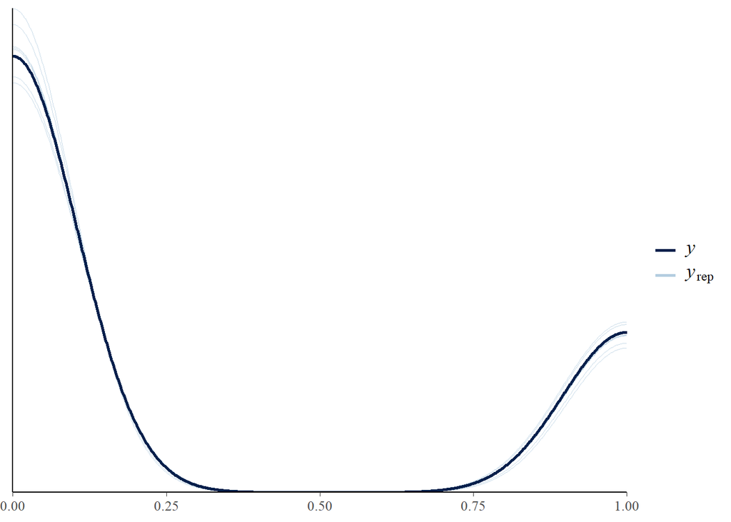

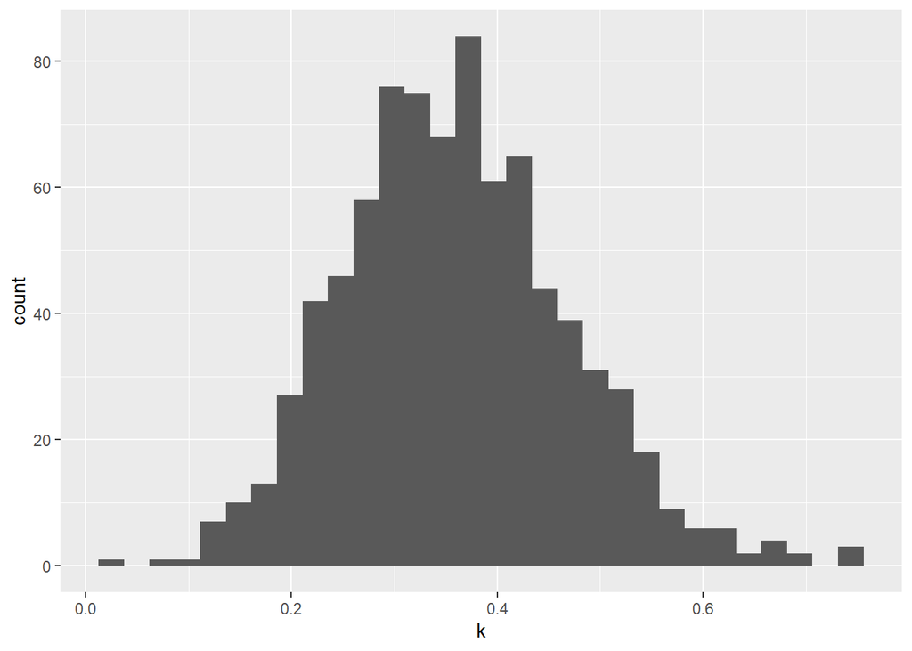

```r
XSectional3 %>%
  mutate(
    k = m3$criteria$loo$diagnostics$pareto_k
  ) %>%
  ggplot(aes(x=k)) + geom_histogram()
```